## Reproducible Research - Week 2 Project

## Loading and preprocessing the data

Setting the working directory to the appropriate folder on my machine and load the relevant libraries.

```r
setwd('/Users/arushiagarwal/Documents/Coursera/John Hopkins course/Reproducible Research')
library("ggplot2")
library("dplyr")
library("grid")
library("gridExtra")
```

1. Load and pre-process the data

```r
unzip('week2.zip')
data <- read.csv('activity.csv', header = TRUE)
```

2. Looking at the summary of data and top 5 rows to get idea of the dataset

```r
str(data)
```

```
## 'data.frame':    17568 obs. of  3 variables:
##  $ steps   : int  NA NA NA NA NA NA NA NA NA NA ...
##  $ date    : Factor w/ 61 levels "2012-10-01","2012-10-02",..: 1 1 1 1 1 1 1 1 1 1 ...
##  $ interval: int  0 5 10 15 20 25 30 35 40 45 ...
```

```r
summary(data)
```

```
##      steps                date          interval
##  Min.   :  0.00   2012-10-01:  288   Min.   :   0.0
##  1st Qu.:  0.00   2012-10-02:  288   1st Qu.: 588.8
##  Median :  0.00   2012-10-03:  288   Median :1177.5
##  Mean   : 37.38   2012-10-04:  288   Mean   :1177.5
##  3rd Qu.: 12.00   2012-10-05:  288   3rd Qu.:1766.2
##  Max.   :806.00   2012-10-06:  288   Max.   :2355.0
##  NA's   :2304     (Other)   :15840
```

```r
head(data)
```

```
##   steps       date interval
## 1    NA 2012-10-01        0
## 2    NA 2012-10-01        5
## 3    NA 2012-10-01       10
## 4    NA 2012-10-01       15
## 5    NA 2012-10-01       20
## 6    NA 2012-10-01       25
```

```r
data$dates <- as.Date(data$date ,"%Y-%m-%d")
```

## What is mean total number of steps taken per day?

1. Calculate the total number of steps taken per day

```r
steps <- aggregate(data$steps, by = list(data$dates), FUN = sum)
names(steps) <- c("Date","Total")
```

2. If you do not understand the difference between a histogram and a barplot, research the difference between them. Make a histogram of the total number of steps taken each day

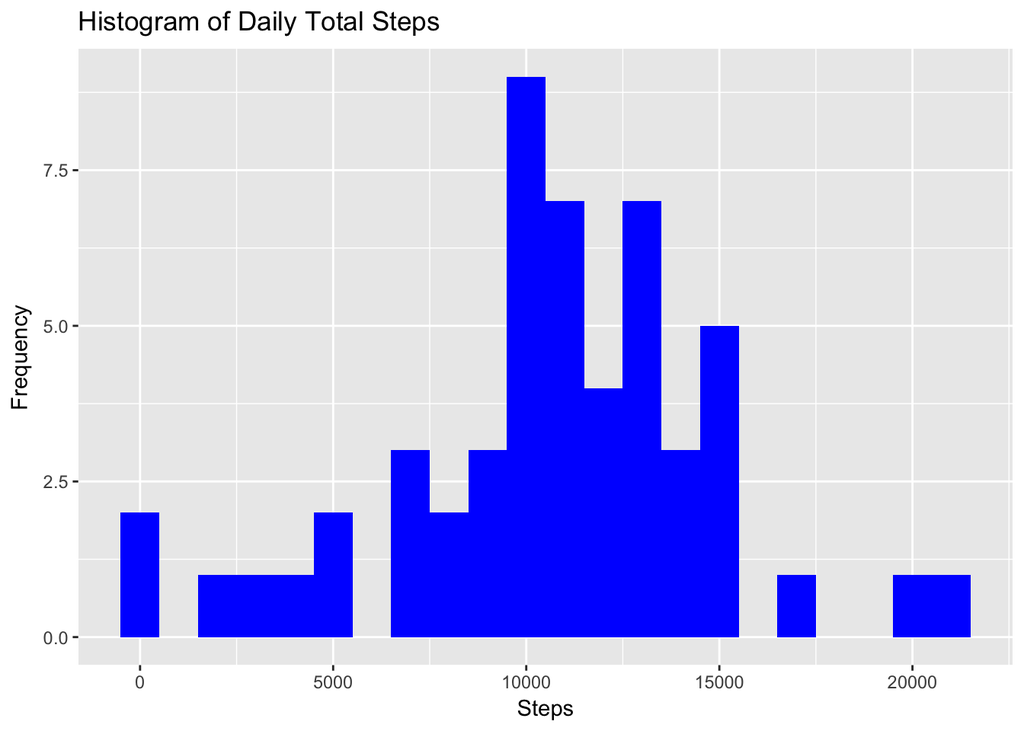

```r
hist <- ggplot(steps, aes(x = Total)) +
  geom_histogram(fill = "blue", binwidth = 1000) +
  labs(title = "Histogram of Daily Total Steps", x = "Steps", y = "Frequency")
print(hist)
```

3. Calculate and report the mean and median of the total number of steps taken per day

```r
steps$mean_steps <- mean(steps$Total, na.rm = TRUE)
steps$median_steps <- median(steps$Total, na.rm = TRUE)
```

## What is the average daily activity pattern?

1. Make a time series plot (i.e. 𝚝𝚢𝚙𝚎 = “𝚕”) of the 5-minute interval (x-axis) and the average number of steps taken, averaged across all days (y-axis) type = “l” means the plot is line graph

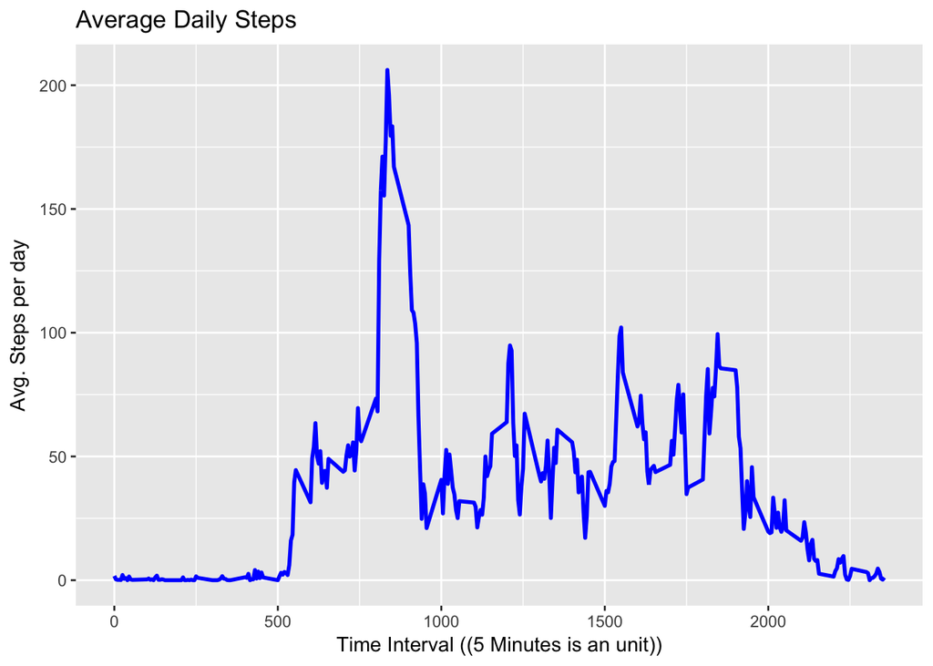

```r
interval <- aggregate(steps ~ interval, data = data, FUN =mean)
ggplot(interval, aes(x = interval , y = steps)) + geom_line(color="blue", size=1) + labs(title = "Average Daily Steps", x = "Time Interval ((5 Minutes is an unit))", y = "Avg. Steps per day")
```

```r
maxinterval <- interval[interval$steps == max(interval$steps, na.rm = TRUE), 1]
```

## Imputing missing values

Note that there are a number of days/intervals where there are missing values (coded as NA). The presence of missing days may introduce bias into some calculations or summaries of the data.

```r
missing_count <- sum(is.na(data))
```

2. Devise a strategy for filling in all of the missing values in the dataset. The strategy does not need to be sophisticated. For example, you could use the mean/median for that day, or the mean for that 5-minute interval, etc.

```r
replace_with_mean <- function(num) replace(num, is.na(num), mean(num, na.rm = TRUE))
meanday <- (data %>% group_by(interval) %>% mutate(steps = replace_with_mean(steps)))
head(meanday)
```

```
## # A tibble: 6 x 4
## # Groups:   interval [6]
##       steps       date interval      dates
##       <dbl>     <fctr>    <int>     <date>
## 1 1.7169811 2012-10-01        0 2012-10-01
## 2 0.3396226 2012-10-01        5 2012-10-01
## 3 0.1320755 2012-10-01       10 2012-10-01
## 4 0.1509434 2012-10-01       15 2012-10-01
## 5 0.0754717 2012-10-01       20 2012-10-01
## 6 2.0943396 2012-10-01       25 2012-10-01
```

3. Create a new dataset that is equal to the original dataset but with the missing data filled in.

```r
imputeddata <- meanday[,c(1,4,3)]
summary(imputeddata)
```

```
##      steps            dates               interval
##  Min.   :  0.00   Min.   :2012-10-01   Min.   :   0.0
##  1st Qu.:  0.00   1st Qu.:2012-10-16   1st Qu.: 588.8
##  Median :  0.00   Median :2012-10-31   Median :1177.5
##  Mean   : 37.38   Mean   :2012-10-31   Mean   :1177.5
##  3rd Qu.: 27.00   3rd Qu.:2012-11-15   3rd Qu.:1766.2
##  Max.   :806.00   Max.   :2012-11-30   Max.   :2355.0
```

4.Make a histogram of the total number of steps taken each day and Calculate and report the mean and median total number of steps taken per day. Do these values differ from the estimates from the first part of the assignment? What is the impact of imputing missing data on the estimates of the total daily number of steps?

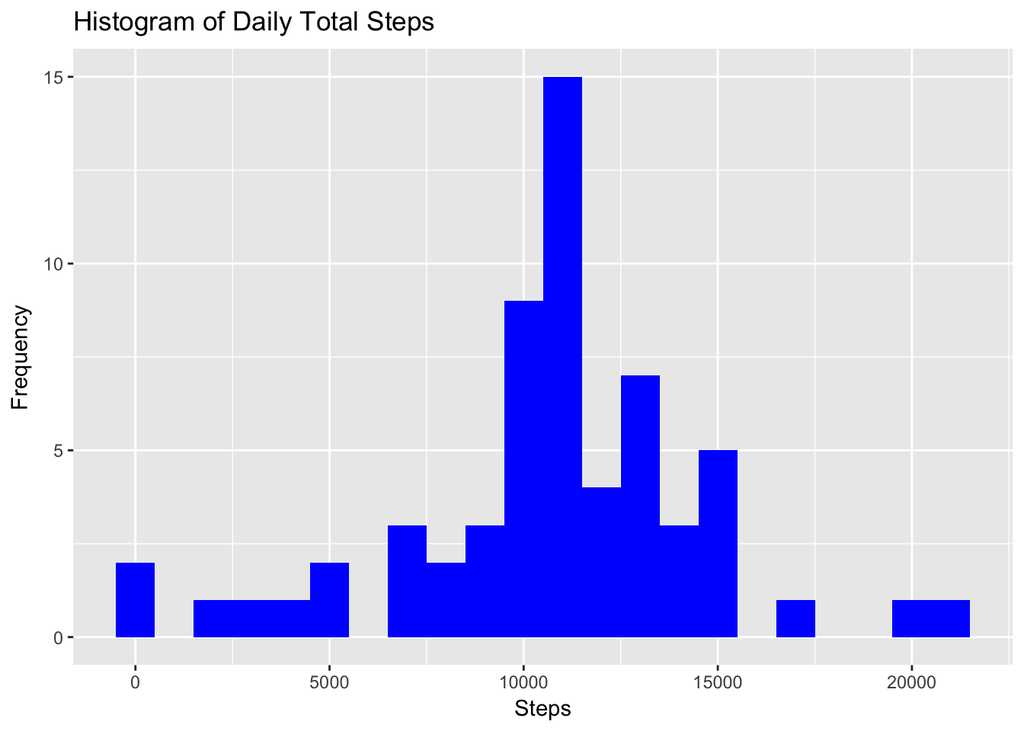

```r
newsteps <- aggregate(imputeddata$steps, by = list(imputeddata$dates), FUN = sum)
names(newsteps) <- c("Date","Total")
newhist <- ggplot(newsteps, aes(x = Total)) +
  geom_histogram(fill = "blue", binwidth = 1000) +
  labs(title = "Histogram of Daily Total Steps", x = "Steps", y = "Frequency")
print(newhist)
```

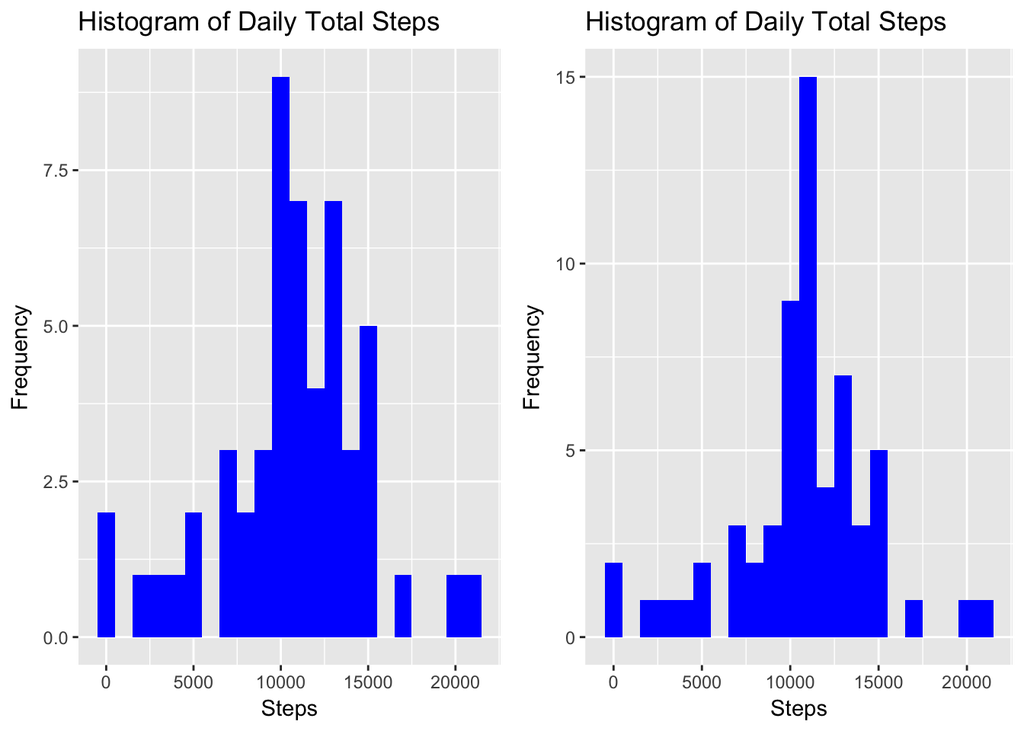

```r
newsteps$mean_steps <- mean(newsteps$Total, na.rm = TRUE)
newsteps$median_steps <- median(newsteps$Total, na.rm = TRUE)

grid.arrange(hist, newhist, ncol = 2)
```

Comparing mean and median

```r
mean(na.omit(steps$Total))
```

```
## [1] 10766.19
```

```r
median(na.omit(steps$Total))
```

```
## [1] 10765
```

```r
mean(newsteps$Total)
```

```
## [1] 10766.19
```

```r
median(newsteps$Total)
```

```
## [1] 10766.19
```

From the comparison, we can see that the highest count of the new version data is larger than the one we have with NAs. The means of each dataset are same. The medians of each dataset are slightly different.

# Are there differences in activity patterns between weekdays and weekends?

1. Create a new factor variable in the dataset with two levels – “weekday” and “weekend” indicating whether a given date is a weekday or weekend day.

```r
imputeddata$WeekendOrWeekday <- ifelse(weekdays(imputeddata$dates) %in% c("Monday", "Tuesday", "Wednesday", "Thursday", "Friday"), "Weekday", "Weekend")
```

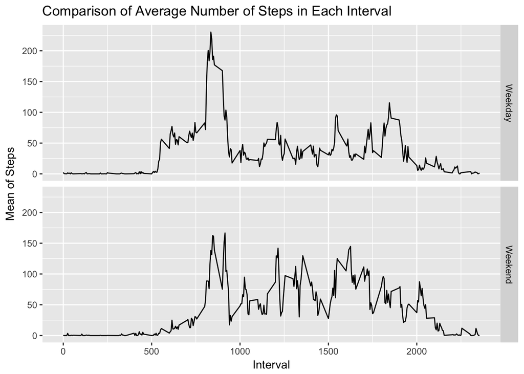

```r
imputeddata <- (imputeddata %>% group_by(interval, WeekendOrWeekday) %>% summarise(Mean = mean(steps)))
ggplot(imputeddata, mapping = aes(x = interval, y = Mean)) + geom_line() +
  facet_grid(WeekendOrWeekday ~.) + xlab("Interval") + ylab("Mean of Steps") +
  ggtitle("Comparison of Average Number of Steps in Each Interval")
```

There are differences in activity patterns between weekdays and weekends. Compared with weekdays, during weekends, people tend to get up late and stay up late. On weekends, people tend to be more active, since their steps are not stable caused of not working.